# Code Splitting Obfuscation - An Empirical Assessment

PoliTo,FBK

2/6/2017

# Results

Descriptive statistics for the experiment

Summary statistics for Correctness and Elapsed Time .

| Treatment | n | n Correct | prop Correct | Time mean | Time sd | T normality |
| --- | --- | --- | --- | --- | --- | --- |
| C | 28 | 25 | 0.89 | 93.71 | 25.93 | 0 |
| TS | 29 | 15 | 0.52 | 99.28 | 27.84 | 0 |
| T | 30 | 20 | 0.67 | 93.07 | 29.19 | 0 |

## H1 Correctness

The proportion of correct completed tasks for the three treatments is reported in figure

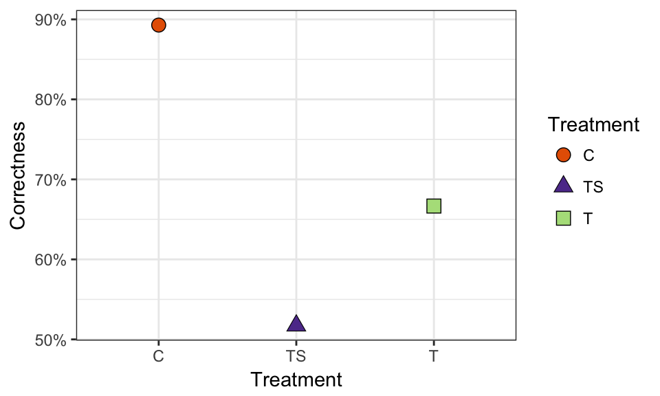

Proportion of correctly completed tasks per Treatment.

Logistic regression of Correctness vs. Treatment

|  | Estimate | Std. Error | z value | Pr(>\|z\|) |
| --- | --- | --- | --- | --- |
| (Intercept) | 0.961 | 0.271 | 3.544 | 0.000 |
| Treatment.L | -1.009 | 0.512 | -1.973 | 0.049 |
| Treatment.Q | 1.092 | 0.423 | 2.580 | 0.010 |

Both splitting treatmens (T and TS) have a significant effect on the correcteness of the attack task results.

## H2: Time

The distribution of elapsed time required to complete the task is reported in figure .

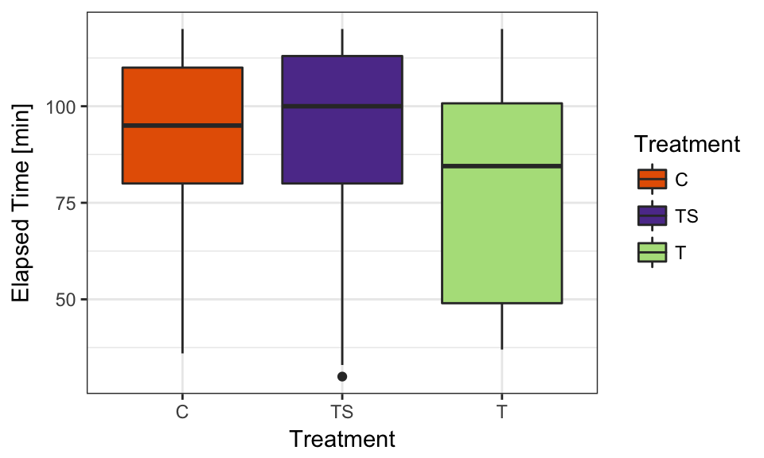

Boxplot of time to complete the task.

The Kruskal-Wallis test result (p-value = 0.3940098) does not allow us to reject the null hypothesis: neither obuscation treatment has a significant effect on the attack task time.

## Co-factors

There three different tests for measuring the C knowledge skill. The cross correlation of the three tests results are shown in the table below:

Cross correlation of the C knowledge tests

|  | Q1.TOT | Q2.TOT | Q3.TOT |
| --- | --- | --- | --- |
| Q1.TOT | 1.00 | 0.49 | 0.13 |
| Q2.TOT | 0.49 | 1.00 | 0.35 |
| Q3.TOT | 0.13 | 0.35 | 1.00 |

Since they all the coefficients are relatively small, we decided to linearly combine the three tests outcomes to build a unique C knowledge score.

In addition we looked into the test 1 alone (just because we like fishing…).

### Correctness and C Skill

The effect of the C knowledge co-factor is reported in figure for both test 1 alone and the combined score.

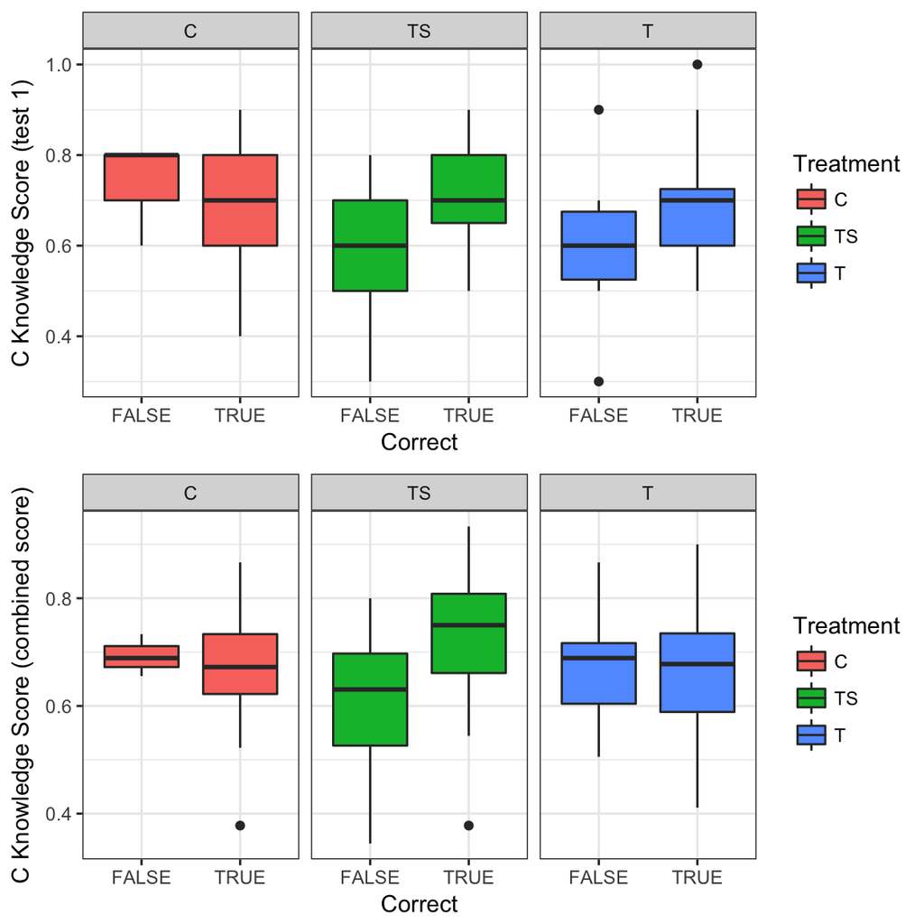

The effect of the C knowledge, represented by the test 1 is reported in the following table:

Logistic regression of Correctness vs. Treatment and C Test 1

|  | Estimate | Std. Error | z value | Pr(>\|z\|) |
| --- | --- | --- | --- | --- |
| (Intercept) | -1.756 | 1.191 | -1.475 | 0.140 |
| Treatment.L | -0.970 | 0.524 | -1.853 | 0.064 |
| Treatment.Q | 1.120 | 0.442 | 2.533 | 0.011 |
| Q1.TOT | 4.153 | 1.808 | 2.297 | 0.022 |

The effect of the C knowledge, represented by the combined score is reported in the following tables:

Logistic regression of Correctness vs. Treatment and Combined Score

|  | Estimate | Std. Error | z value | Pr(>\|z\|) |
| --- | --- | --- | --- | --- |
| (Intercept) | -0.941 | 1.345 | -0.699 | 0.484 |
| Treatment.L | -0.994 | 0.515 | -1.930 | 0.054 |
| Treatment.Q | 1.109 | 0.430 | 2.579 | 0.010 |
| C.SCORE | 2.857 | 1.996 | 1.432 | 0.152 |

We observe no significant effect of the combine C knwoledge score on the correctness.

### Time and C Skill

The relationship between the elapsed time and the C skill (both test 1 and combined score) is reported in figure .

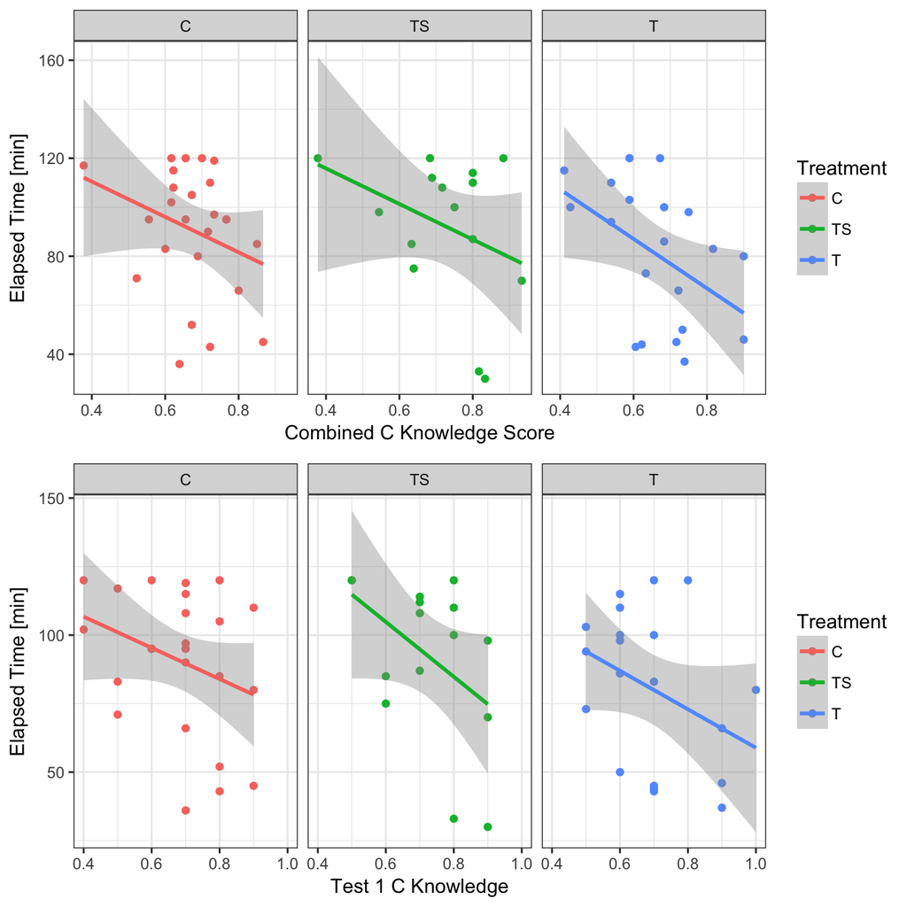

The permutation test anova for C knowledge test 1 is reported in the following table:

Logistic regression of Elapsed Time vs. Treatment and C Test 1

|  | Estimate | Iter | Pr(Prob) |
| --- | --- | --- | --- |
| (Intercept) | 88.034 | 5000 | 0.018 |
| Treatment.L | -6.706 | 660 | 0.132 |
| Treatment.Q | -7.630 | 147 | 0.408 |
| Q1.TOT | -70.994 | 5000 | 0.006 |

The test 1 C knowledge has a significant effect on the elapsed time. With test 1 we achieve an R^2=0.1172919.

Logistic regression of Elapsed Time vs. Treatment and Combined Score

|  | Estimate | Iter | Pr(Prob) |
| --- | --- | --- | --- |
| (Intercept) | 88.134 | 5000 | 0.006 |
| Treatment.L | -7.723 | 66 | 0.606 |
| Treatment.Q | -9.198 | 743 | 0.120 |
| C.SCORE | -83.152 | 5000 | 0.003 |

The combined score for C knowledge has a significant effect on the elapsed time.

With the combined score we achieve an R^2= 0.1228415.

## Type of attack

We identified two distinct categories of attack:

- internal: the computation inside specific functions has been altered,
- external: the actual parameter in function calls have been changed.

It is important to emphasize that during the attack task, both type could have been applied to achieve the goal.

Depending on the type of treatment one approach was easier to apply.

We can observe the number and percentage of participants that applied the two attach types in the following table.

| Treatment | n | internal | internal.pct | external | external.pct | both | both.pct |
| --- | --- | --- | --- | --- | --- | --- | --- |
| C | 28 | 20 | 71.4 | 13 | 46.4 | 5 | 17.9 |
| TS | 29 | 13 | 44.8 | 20 | 69.0 | 5 | 17.2 |
| T | 30 | 14 | 46.7 | 24 | 80.0 | 9 | 30.0 |

We observe that 2 participants did not reported which strategy was applied!

We observe that clear code was much easier to attack with an internal approach, the statistical significance of such a difference can be tested using a Fisher test comparing clear vs non-clear (either medium or small splitting).

```
##
##  Fisher's Exact Test for Count Data
##
## data:  d$Treatment == "C" and d$Internal
## p-value = 0.03757
## alternative hypothesis: true odds ratio is not equal to 1
## 95 percent confidence interval:
##  1.032971 8.981842
## sample estimates:
## odds ratio
##   2.925874
```

```
##
##  Fisher's Exact Test for Count Data
##
## data:  d$Treatment != "C" and d$External
## p-value = 0.01527
## alternative hypothesis: true odds ratio is not equal to 1
## 95 percent confidence interval:
##  1.183089 9.683117
## sample estimates:
## odds ratio
##   3.332235
```

### Attack strategy vs. Success

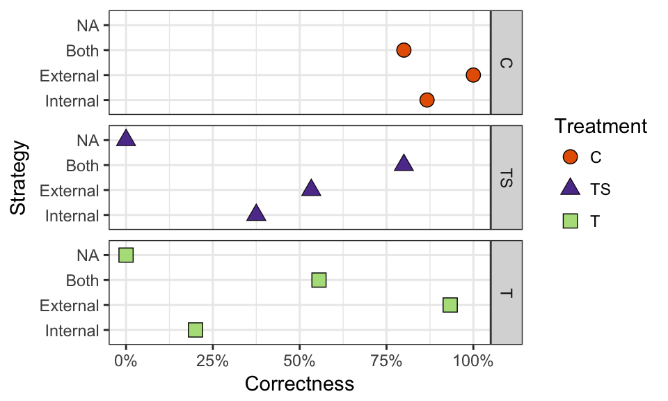

Success rate for different strategies by treatment

### Attack strategy vs. Time

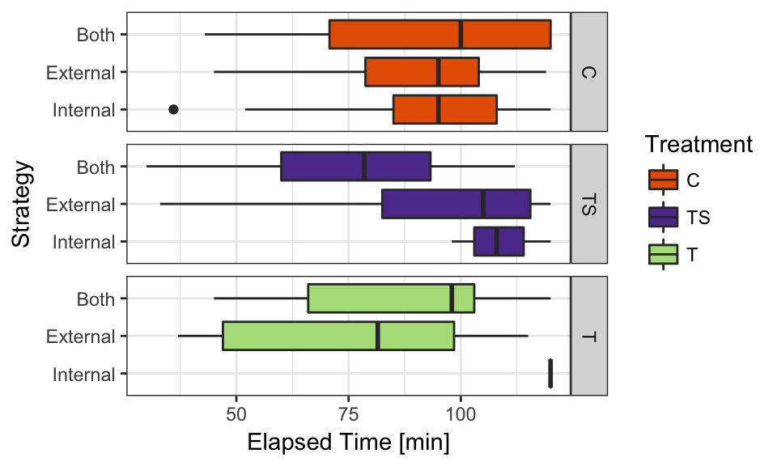

Attack time for different strategies by treatment